# Final Project

Drew Insley

12/04/18

## Set Up

```r
library(DataComputing)
library(rvest)
library(lubridate)
library(tidyr)
```

## Project

```r
# Get the Data
getwd()
```

```
## [1] "/Users/drewinsley/InsleyFinalProject"
```

```r
setwd("~/Downloads")

FireIncidents <- read.csv("Fire_Incident_Dispatch_Data.csv")
```

```r
# Inspect the Data
str(FireIncidents)
```

```
## 'data.frame':    2755750 obs. of  29 variables:
##  $ STARFIRE_INCIDENT_ID          : num  1.3e+15 1.3e+15 1.3e+15 1.3e+15 1.3e+15 ...
##  $ INCIDENT_DATETIME             : Factor w/ 2724240 levels "01/01/2013 01:01:16 PM",..: 1337 1338 1339 1343 1345 1347 1349 1350 1351 1352 ...
##  $ ALARM_BOX_BOROUGH             : Factor w/ 5 levels "BRONX","BROOKLYN",..: 1 3 4 4 4 2 3 4 1 1 ...
##  $ ALARM_BOX_NUMBER              : int  2147 818 9656 4019 7412 1328 688 9604 2897 2275 ...
##  $ ALARM_BOX_LOCATION            : Factor w/ 19762 levels "1 AV & LUIS M MARIN BLVD/116 ST",..: 17614 363 11928 19678 7067 1682 3543 4382 19244 8958 ...
##  $ INCIDENT_BOROUGH              : Factor w/ 5 levels "BRONX","BROOKLYN",..: 1 3 4 4 4 2 3 4 1 1 ...
##  $ ZIPCODE                       : int  10454 10036 11418 11385 11103 11232 10001 11418 10472 10451 ...
##  $ POLICEPRECINCT                : int  40 18 102 104 114 72 14 102 43 40 ...
##  $ CITYCOUNCILDISTRICT           : int  8 3 29 34 26 38 3 32 18 17 ...
##  $ COMMUNITYDISTRICT             : int  201 104 409 405 401 307 105 409 209 201 ...
##  $ COMMUNITYSCHOOLDISTRICT       : int  7 2 27 24 30 15 2 27 12 7 ...
##  $ CONGRESSIONALDISTRICT         : int  15 10 5 7 14 10 12 7 15 15 ...
##  $ ALARM_SOURCE_DESCRIPTION_TX   : Factor w/ 10 levels "BARS","DEFAULT RECORD",..: 3 8 3 8 9 8 9 9 9 7 ...
##  $ ALARM_LEVEL_INDEX_DESCRIPTION : Factor w/ 10 levels "10-75 Signal (Request for all hands alarm)",..: 8 8 8 8 8 8 8 8 8 8 ...
##  $ HIGHEST_ALARM_LEVEL           : Factor w/ 9 levels "All Hands Working",..: 5 5 5 5 5 5 5 5 5 5 ...
##  $ INCIDENT_CLASSIFICATION       : Factor w/ 66 levels "Abandoned Derelict Vehicle Fire",..: 23 2 23 2 61 2 5 21 5 5 ...
##  $ INCIDENT_CLASSIFICATION_GROUP : Factor w/ 6 levels "Medical Emergencies",..: 1 3 1 3 3 3 3 5 3 3 ...
##  $ DISPATCH_RESPONSE_SECONDS_QY  : int  666 56 8 77 22 36 9 13 22 45 ...
##  $ FIRST_ASSIGNMENT_DATETIME     : Factor w/ 2718154 levels "","01/01/2013 01:01:30 PM",..: 1372 1342 1341 1348 1346 1350 1351 1352 1354 1355 ...
##  $ FIRST_ACTIVATION_DATETIME     : Factor w/ 2704501 levels "","01/01/2013 01:01:58 PM",..: 1365 1335 1333 1340 1339 1342 1343 1344 1346 1348 ...
##  $ FIRST_ON_SCENE_DATETIME       : Factor w/ 2328086 levels "","01/01/2013 01:00:18 AM",..: 1215 1200 1189 1192 1195 1196 1211 1191 1203 1212 ...
##  $ INCIDENT_CLOSE_DATETIME       : Factor w/ 2723001 levels "01/01/2013 01:00:00 AM",..: 1382 1407 1372 1395 1432 1377 1410 1366 1391 1373 ...
##  $ VALID_DISPATCH_RSPNS_TIME_INDC: Factor w/ 1 level "N": 1 1 1 1 1 1 1 1 1 1 ...
##  $ VALID_INCIDENT_RSPNS_TIME_INDC: Factor w/ 2 levels "N","Y": 1 2 2 2 2 2 2 2 2 2 ...
##  $ INCIDENT_RESPONSE_SECONDS_QY  : int  843 506 218 278 316 310 555 136 385 527 ...
##  $ INCIDENT_TRAVEL_TM_SECONDS_QY : int  177 450 210 201 294 274 546 123 363 482 ...
##  $ ENGINES_ASSIGNED_QUANTITY     : int  1 1 1 3 2 1 0 3 0 0 ...
##  $ LADDERS_ASSIGNED_QUANTITY     : int  0 1 0 2 1 1 2 2 1 1 ...
##  $ OTHER_UNITS_ASSIGNED_QUANTITY : int  0 1 0 1 1 1 0 1 0 0 ...
```

```r
# Clean up the data
pattern <- ("[0-9]{2}[:][0-9]{2}[:][0-9]{2}")

FireIncidents <-
FireIncidents %>%
  select(INCIDENT_BOROUGH, INCIDENT_DATETIME, ENGINES_ASSIGNED_QUANTITY, INCIDENT_CLASSIFICATION_GROUP, ZIPCODE, LADDERS_ASSIGNED_QUANTITY) %>%
  rename(Borough = INCIDENT_BOROUGH, Date = INCIDENT_DATETIME, Engines = ENGINES_ASSIGNED_QUANTITY, Type = INCIDENT_CLASSIFICATION_GROUP, Ladders = LADDERS_ASSIGNED_QUANTITY, ZipCode = ZIPCODE) %>%
  mutate(Date = gsub(pattern, " ", Date)) %>%
  mutate(Date = gsub("[AMP]{2}", " ", Date)) %>%
  mutate(Date = mdy(Date))

FireIncidents
```

```
##                          Borough       Date Engines                   Type
## 1                          BRONX 2013-01-01       1    Medical Emergencies
## 2                      MANHATTAN 2013-01-01       1 NonMedical Emergencies
## 3                         QUEENS 2013-01-01       1    Medical Emergencies
## 4                         QUEENS 2013-01-01       3 NonMedical Emergencies
## 5                         QUEENS 2013-01-01       2 NonMedical Emergencies
## 6                       BROOKLYN 2013-01-01       1 NonMedical Emergencies
## 7                      MANHATTAN 2013-01-01       0 NonMedical Emergencies
## 8                         QUEENS 2013-01-01       3    NonStructural Fires
## 9                          BRONX 2013-01-01       0 NonMedical Emergencies
## 10                         BRONX 2013-01-01       0 NonMedical Emergencies
## 11                      BROOKLYN 2013-01-01       3        NonMedical MFAs
## 12                     MANHATTAN 2013-01-01       0 NonMedical Emergencies
## 13                         BRONX 2013-01-01       0 NonMedical Emergencies
## 14                         BRONX 2013-01-01       1    NonStructural Fires
```

[output cut: 33320 more lines]

**Now we have a dataset we can use! Let’s make a chart of counts for incidents and ladders by borough, so that we can graph these data!**

```r
# Make a chart of counts
FireCount <-
FireIncidents %>%
  group_by(Borough) %>%
  summarise(Incidents=n()) %>%
  arrange(desc(Incidents))

FireLadders <-
FireIncidents %>%
  group_by(Borough) %>%
  summarise(Ladders=sum(Ladders)) %>%
  arrange(desc(Ladders))


FireJoin <-
  FireCount %>%
  inner_join(FireLadders)
FireJoin
```

```
## # A tibble: 5 x 3
##   Borough                  Incidents Ladders
##   <fct>                        <int>   <int>
## 1 BROOKLYN                    777725  566653
## 2 MANHATTAN                   751041  555519
## 3 BRONX                       549277  415218
## 4 QUEENS                      541950  383284
## 5 RICHMOND / STATEN ISLAND    135757   89565
```

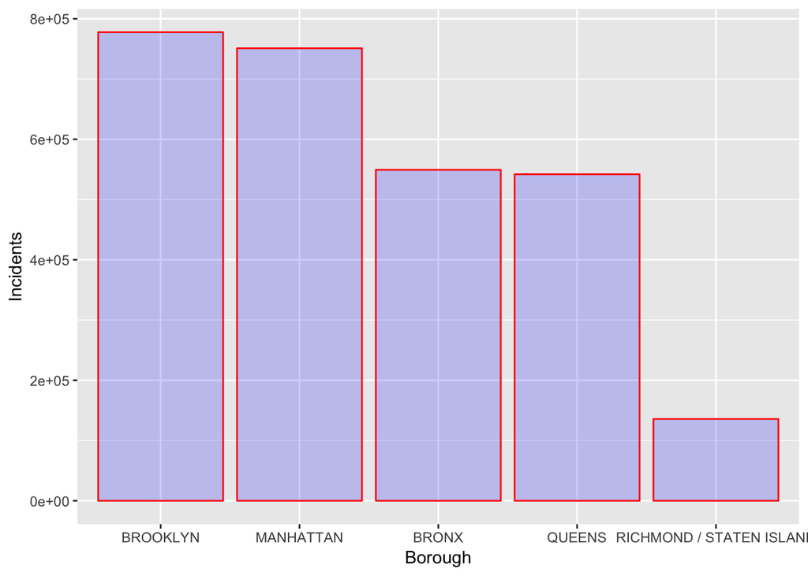

```r
# Which borough had the most number of fire incidents?
FireJoin %>%
  ggplot(aes(reorder(Borough, desc(Incidents)), Incidents)) +
  geom_bar(stat="identity", fill="blue", color="red", alpha=.2) +
  xlab("Borough")
```

**The graph shows the descending order of fire incidents in the five boroughs of New York. As one can see, Brooklyn had the most fire incidents with 777,725 occurances. Let’s see if the number of ladders deployed by borough will match with the amount of incidents by borough.**

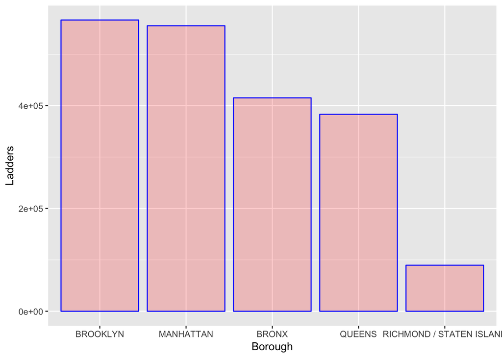

```r
# How many ladders were deployed?
FireJoin %>%
  ggplot(aes(reorder(Borough, desc(Ladders)), Ladders)) +
  geom_bar(stat="identity", fill="red", color="blue", alpha=.2) +
  xlab("Borough")
```

**The number of ladders deployed does match with the amount of fire incidents by borough. In fact, the descending order is the exact same. To further visualize this connection, we can plot ladders and incidents on a scatterplot.**

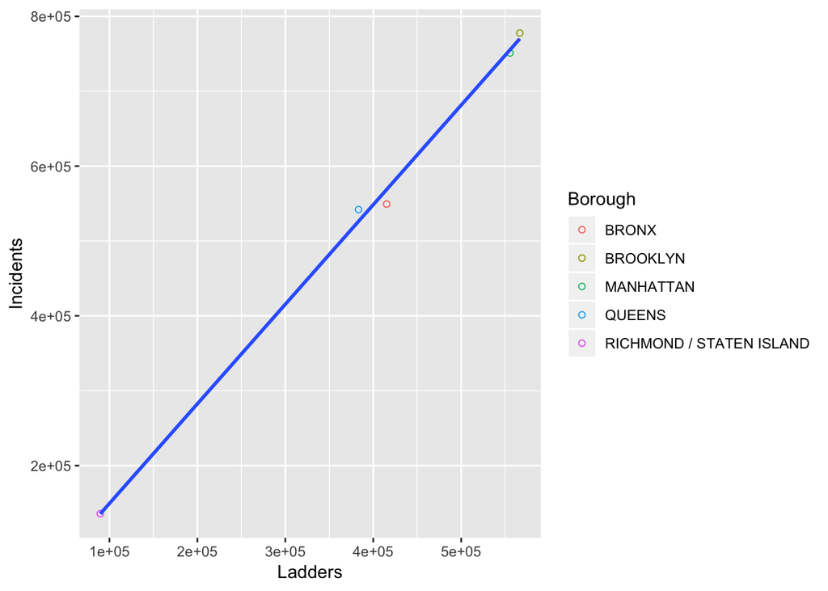

```r
# Plot ladders & incidents on a scatterplot
FireJoin %>%
  ggplot(aes(Ladders, Incidents)) +
  geom_point(shape=1, aes(color= Borough)) +
  geom_smooth(method=lm, se=FALSE)
```

**As the scatterplot shows, there is a clear linear relationship between the two variables. This means that ladders deployed and number of fires are heavily correlated. Let’s see which days these fires were most likely to occur.**

```r
# What days were these fires most likely to occur?
FireDays <-
FireIncidents %>%
  group_by(Date) %>%
  summarise(Count=n()) %>%
  mutate(Rank = rank(desc(Count))) %>%
  select(Date, Rank) %>%
  arrange(Rank)

FireDays %>%
  head(5)
```

```
## # A tibble: 5 x 2
##   Date        Rank
##   <date>     <dbl>
## 1 2016-02-15     1
## 2 2016-02-16     2
## 3 2015-02-22     3
## 4 2015-02-16     4
## 5 2015-02-17     5
```

```r
pattern <- ("[0-7]{4}[-]")

FireTypes <-
FireIncidents %>%
  select(Date, Type) %>%
  mutate(Month = gsub(pattern, " ", Date)) %>%
  mutate(Month = gsub(("[-][0-9]{2}"), " ", Date)) %>%
  group_by(Month, Type) %>%
  summarise(Count=n()) %>%
  filter(Type == 'Medical Emergencies') %>%
  arrange(desc(Count))

FireTypes
```

```
## # A tibble: 5 x 3
## # Groups:   Month [5]
##   Month    Type                 Count
##   <chr>    <fct>                <int>
## 1 "2017  " Medical Emergencies 281338
## 2 "2016  " Medical Emergencies 272697
## 3 "2015  " Medical Emergencies 266689
## 4 "2014  " Medical Emergencies 227905
## 5 "2013  " Medical Emergencies 219445
```